# Why Trumps Inaugaration Speech Makes Him Unique

Peter Li (pwl2107)

9/17/2017

## Overview

In this report, we will explore the inaugaration speechs to understand how Trump is similar and dissimilar to his predecessors and what drives it.

## Data Processing

### Read in Speeches

```r
folder.path="../data/InauguralSpeeches/"
speeches=list.files(path = folder.path, pattern = "*.txt")
prex.out=substr(speeches, 6, nchar(speeches)-4)

ff.all<-Corpus(DirSource(folder.path))
```

### Basic Text Processing

```r
ff.all<-tm_map(ff.all, stripWhitespace)
ff.all<-tm_map(ff.all, content_transformer(tolower))
ff.all<-tm_map(ff.all, removeWords, stopwords("english"))
ff.all<-tm_map(ff.all, removeWords, character(0))
ff.all<-tm_map(ff.all, removePunctuation)

tdm.all<-TermDocumentMatrix(ff.all)

tdm.tidy=tidy(tdm.all)

tdm.overall=summarise(group_by(tdm.tidy, term), sum(count))

tdm.trump=tdm.tidy %>% filter(document == 'inaugDonaldJTrump-1.txt')
tdm.trump=summarise(group_by(tdm.trump, term), sum(count))
```

Just to get a qualitative comparison of Trump’s Inaugaration vs. Other Inaugaration, we compare the word clouds. Here is the overall:

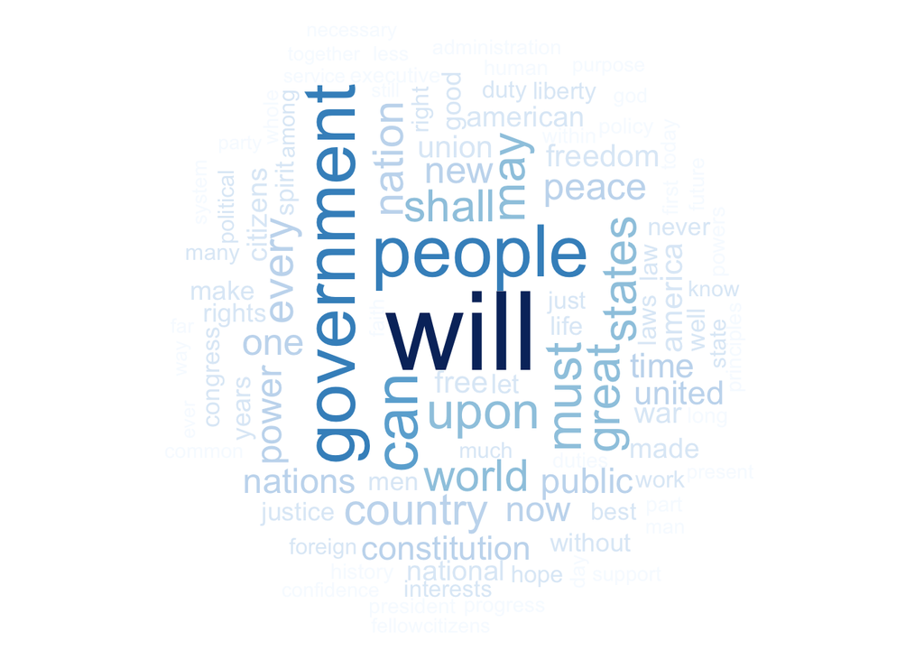

```r
wordcloud(tdm.overall$term, tdm.overall$`sum(count)`,
          scale=c(5,0.5),
          max.words=100,
          min.freq=1,
          random.order=FALSE,
          rot.per=0.3,
          use.r.layout=T,
          random.color=FALSE,
          colors=brewer.pal(9,"Blues"))
```

And here is Trump:

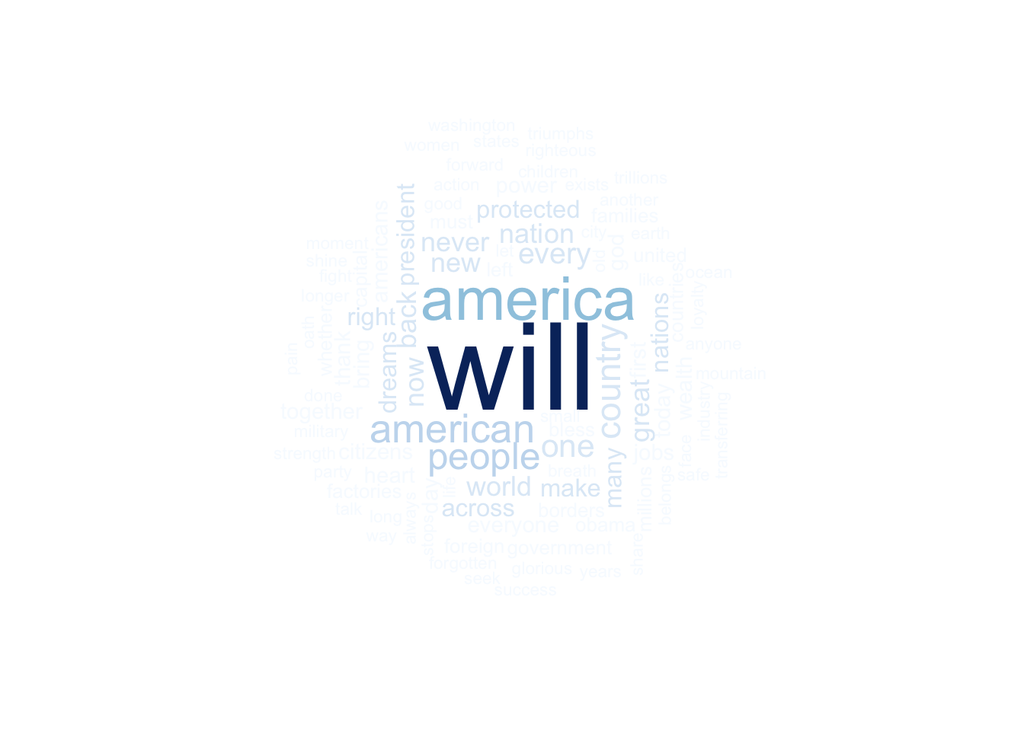

```r
wordcloud(tdm.trump$term, tdm.trump$`sum(count)`,
          scale=c(5,0.5),
          max.words=100,
          min.freq=1,
          random.order=FALSE,
          rot.per=0.3,
          use.r.layout=T,
          random.color=FALSE,
          colors=brewer.pal(9,"Blues"))
```

Because of the fact that overall contains many more documents than just Trump, there is more diversity in the overall word cloud. However, Trump word cloud focuses more heavily on the world Will and not much else, suggesting that his speech was far less focused/diverse than others. There is also less focus on things like justice, freedom, unity, etc. in Trump compared to overall.

### Sentence Text Processing

```r
speech.list = readtext("../data/InauguralSpeeches/*")
colnames(speech.list) = c('doc_id','fulltext')

sentence.list=data.frame()
for(i in 1:nrow(speech.list)){
  sentences=sent_detect(speech.list$fulltext[i],
                        endmarks = c("?", ".", "!", "|",";"))
  if(length(sentences)>0){
    emotions=get_nrc_sentiment(sentences)
    word.count=word_count(sentences)
    # colnames(emotions)=paste0("emo.", colnames(emotions))
    # in case the word counts are zeros?
    emotions=diag(1/(word.count+0.01))%*%as.matrix(emotions)
    sentence.list=rbind(sentence.list,
                        cbind(speech.list[i,-ncol(speech.list)],
                              sentences=as.character(sentences),
                              word.count,
                              emotions,
                              sent.id=1:length(sentences)
                              )
    )
  }
}

sentence.list=
  sentence.list%>%
  filter(!is.na(word.count))
```

## Data Analysis

To analyze the data, we will look at both sentence length and sentiment analysis to compare the speeches.

### Sentence Length

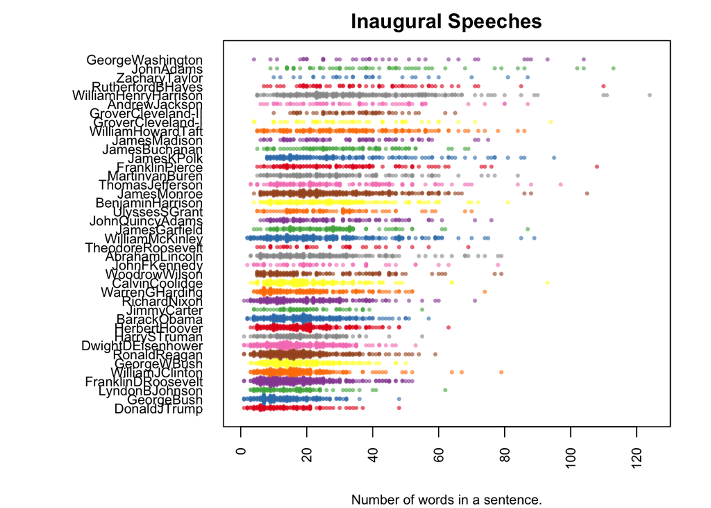

```r
sentence.list$word.count = as.numeric(as.character(sentence.list$word.count))
sentence.list.sel=sentence.list
sentence.list.sel$V1 = substr(sentence.list.sel$V1,6,nchar(as.character(sentence.list.sel$V1))-6)
sentence.list.sel$File=factor(sentence.list.sel$V1)

sentence.list.sel$FileOrdered=reorder(sentence.list.sel$File,
                                  sentence.list.sel$word.count,
                                  mean,
                                  order=T)
par(mar=c(4, 11, 2, 2))

beeswarm(word.count~FileOrdered,
         data=sentence.list.sel,
         horizontal = TRUE,
         pch=16, col=alpha(brewer.pal(9, "Set1"), 0.6),
         cex=0.55, cex.axis=0.8, cex.lab=0.8,
         spacing=5/nlevels(sentence.list.sel$FileOrdered),
         las=2, ylab="", xlab="Number of words in a sentence.",
         main="Inaugural Speeches")
```

```r
sentence.list%>%
  filter(V1=="inaugDonaldJTrump-1.txt",
         word.count<=3) %>%
  select(sentences)
```

```
##            sentences
## 1         Thank you.
## 2                 C.
## 3         Thank you.
## 4     God bless you.
## 5         Thank you.
## 6 God bless America.
```

And so, we see that compared to the other presidents, Donald Trump’s speech tended to have shorter sentences, implying a lower level of sophistication. And upon looking at his short sentences, he repeats the same few short sentences.

### Sentiment Analysis

#### Sentence Length Variation

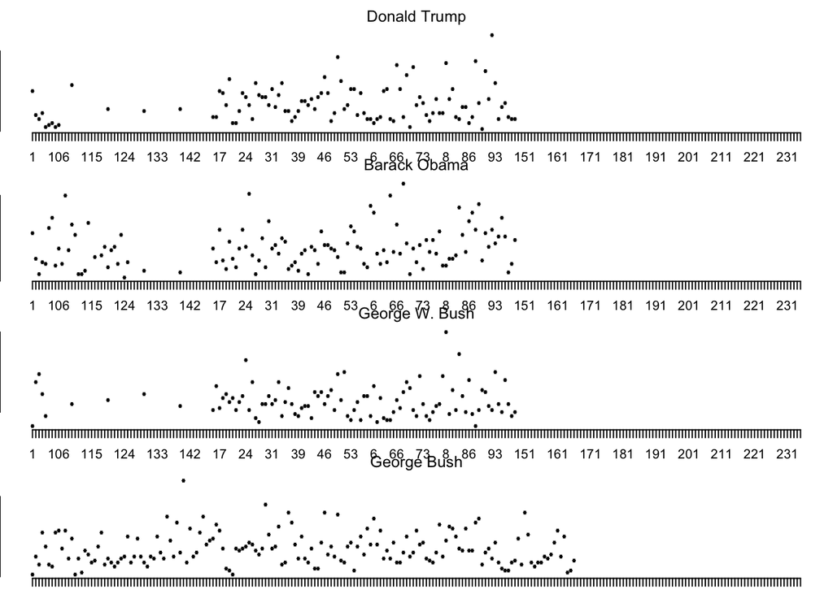

```r
sentence.list$File = substr(sentence.list$V1,6,nchar(as.character(sentence.list$V1))-6)
sentence.list$type = 'inaug'
sentence.list$Term = substr(sentence.list$V1,nchar(as.character(sentence.list$V1))-4,nchar(as.character(sentence.list$V1))-4)

sentence.list$anger = as.numeric(as.character(sentence.list$anger))
sentence.list$anticipation = as.numeric(as.character(sentence.list$anticipation))
sentence.list$disgust = as.numeric(as.character(sentence.list$disgust))
sentence.list$fear = as.numeric(as.character(sentence.list$fear))
sentence.list$joy = as.numeric(as.character(sentence.list$joy))
sentence.list$sadness = as.numeric(as.character(sentence.list$sadness))
sentence.list$surprise = as.numeric(as.character(sentence.list$surprise))
sentence.list$trust = as.numeric(as.character(sentence.list$trust))
sentence.list$negative = as.numeric(as.character(sentence.list$negative))
sentence.list$positive = as.numeric(as.character(sentence.list$positive))

par(mfrow=c(4,1), mar=c(1,0,2,0), bty="n", font.main=1)

f.plotsent.len(In.list=sentence.list, InFile="DonaldJTrump",
               InType="inaug", InTerm=1, President="Donald Trump")

f.plotsent.len(In.list=sentence.list, InFile="BarackObama",
               InType="inaug", InTerm=1, President="Barack Obama")

f.plotsent.len(In.list=sentence.list, InFile="GeorgeWBush",
               InType="inaug", InTerm=1, President="George W. Bush")

f.plotsent.len(In.list=sentence.list, InFile="GeorgeBush",
               InType="inaug", InTerm=1, President="George Bush")
```

So in terms of sentence length variation, we see the same general trends/volatility.

#### Emotion Analysis

##### Highly Emotional Examples

```r
print("Donald Trump")
```

```
## [1] "Donald Trump"
```

```r
speech.df=tbl_df(sentence.list)%>%
  filter(File=="DonaldJTrump", type=="inaug", Term==1, word.count>=5)%>%
  select(sentences, anger:trust)
speech.df=as.data.frame(speech.df)
as.character(speech.df$sentences[apply(speech.df[,-1], 2, which.max)])
```

```
## [1] "There should be no fear."
## [2] "America will start winning again, winning like never before."
## [3] "America will start winning again, winning like never before."
## [4] "There should be no fear."
## [5] "buy American and hire American."
## [6] "America will start winning again, winning like never before."
## [7] "The bible tells us how good and pleasant it is when God's people live together in unity."
## [8] "At the center of this movement is a crucial conviction, that a nation exists to serve its citizens."
```

```r
print("Barack Obama")
```

```
## [1] "Barack Obama"
```

```r
speech.df=tbl_df(sentence.list)%>%
  filter(File=="BarackObama", type=="inaug", word.count>=4)%>%
  select(sentences, anger:trust)
speech.df=as.data.frame(speech.df)
as.character(speech.df$sentences[apply(speech.df[,-1], 2, which.max)])
```

```
## [1] "The Capital was abandoned."
## [2] "This is the journey we continue today."
## [3] "Our capacity remains undiminished."
## [4] "Our capacity remains undiminished."
## [5] "when the wages of honest labor liberate families from the brink of hardship."
## [6] "The Capital was abandoned."
## [7] "when the wages of honest labor liberate families from the brink of hardship."
## [8] "We affirm the promise of our democracy."
```

```r
print("George W Bush")
```

```
## [1] "George W Bush"
```

```r
speech.df=tbl_df(sentence.list)%>%
  filter(File=="GeorgeWBush", type=="inaug", Term==1, word.count>=5)%>%
  select(sentences, anger:trust)
speech.df=as.data.frame(speech.df)
as.character(speech.df$sentences[apply(speech.df[,-1], 2, which.max)])
```

```
## [1] "Abandonment and abuse are not acts of God;"
## [2] "God bless you all, and God bless America."
## [3] "Where there is suffering, there is duty."
## [4] "Abandonment and abuse are not acts of God;"
## [5] "God bless you all, and God bless America."
## [6] "Abandonment and abuse are not acts of God;"
## [7] "Abandonment and abuse are not acts of God;"
## [8] "God bless you all, and God bless America."
```

```r
print("George Bush")
```

```
## [1] "George Bush"
```

```r
speech.df=tbl_df(sentence.list)%>%
  filter(File=="GeorgeBush", type=="inaug", Term==1, word.count>=4)%>%
  select(sentences, anger:trust)
speech.df=as.data.frame(speech.df)
as.character(speech.df$sentences[apply(speech.df[,-1], 2, which.max)])
```

```
## [1] "There are the homeless, lost and roaming."
## [2] "But hope is good, and so is strength and vigilance."
## [3] "Help us remember, Lord."
## [4] "That war cleaves us still."
## [5] "And God bless the United States of America."
## [6] "There are the homeless, lost and roaming."
## [7] "in all things, generosity."
## [8] "But hope is good, and so is strength and vigilance."
```

##### Emotion Distribution

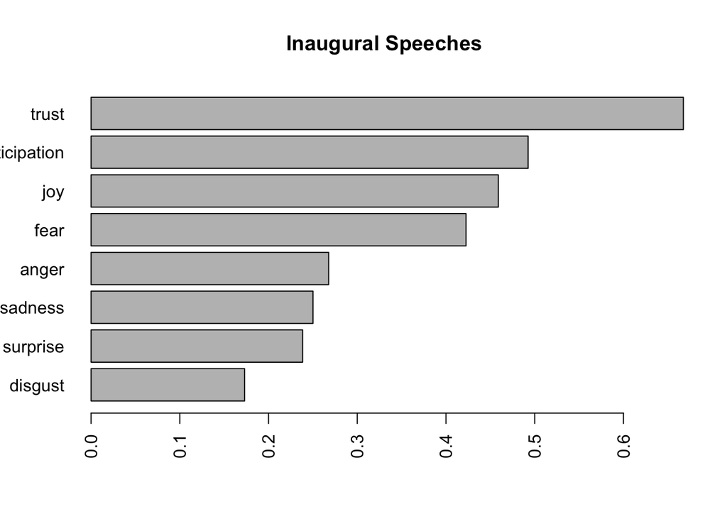

```r
emo.means=colMeans(select(sentence.list, anger:trust)>0.01)
barplot(emo.means[order(emo.means)], las=2, col='grey', horiz=T, main="Inaugural Speeches")
```

```r
tmp = colMeans(select(sentence.list %>% filter(File == 'DonaldJTrump'), anger:trust)>0.01)
tmp[order(tmp)]
```

```
##      disgust      sadness     surprise        anger         fear
##   0.06603774   0.09433962   0.12264151   0.13207547   0.20754717
## anticipation          joy        trust
##   0.33018868   0.33018868   0.46226415
```

And so, we see that trumps distribution of emotions tends to follow the same pattern as other presidents (chart is all presidents and the numbers printed after are for Trump)

##### Clustering based on Emotions

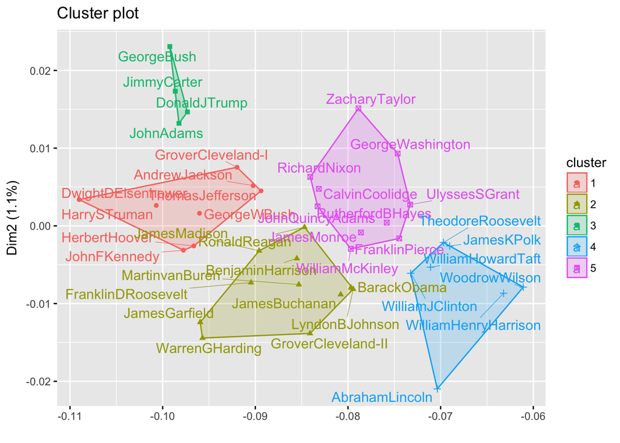

```r
presid.summary=tbl_df(sentence.list)%>%
  filter(type=="inaug")%>%
  group_by(File)%>%
  summarise(
    anger=mean(anger),
    anticipation=mean(anticipation),
    disgust=mean(disgust),
    fear=mean(fear),
    joy=mean(joy),
    sadness=mean(sadness),
    surprise=mean(surprise),
    trust=mean(trust)
  )

presid.summary=as.data.frame(presid.summary)
rownames(presid.summary)=as.character((presid.summary[,1]))
km.res=kmeans(presid.summary[,-1], iter.max=200,
              5)
fviz_cluster(km.res,
             stand=F, repel= TRUE,
             data = presid.summary[,-1], xlab="", xaxt="n",
             show.clust.cent=FALSE)
```

And based on the emotion clustering, Trump is grouped in the smallest cluster – suggesting that his speech is more unique as it is not similar to that many other presidents.

## Conclusion

Overall, Donald Trump’s speech is similar to other speechs in terms of structure (sentence length variation and emotion distribution). However, Trump’s speech differs greatly in terms of content and sophistication. Trump tends to have shorter sentences, implying lower sophistication. And his content seems very superficial (word cloud shows very little variation in terms of content) and distinct (clustered into group with fewest other presidents).